# Practical PCA

2016-11-30

## Teachers and slides

- **Malte Thodberg**
- PhD Student ~ 1.5 / 3 years
- Focus: Clinical Bioinformatics
- Mail: `malte.thodberg@bio.ku.dk`
- Background: BSc Molecular Biomedicine & MSc Bioinformatics

## Practical Outline

The plan:

- Brief mention of data dimensionality.
- Brief example of PCA using small example datasets.
- Normalizing expression using edgeR's `cpm` function.
- Exploring RNA-Seq data with PCA.

## Datasets

Example datasets:

- `iris` dataset from `datasets` (default R-package).
- `oliveoil` dataset from the `pdfCluster` package.

Real datasets:

- `zebrafish` dataset
- `fission` dataset
- `pasilla` dataset

Advanced dataset for playing around:

- `tissues` dataset

## Plotting libraries

The plot examples will mainly be based on the popular `ggplot2` package, since `ggplot2` have powerful features for coloring plots:

```r
library(ggplot2)
```

But feel free to use whatever package you like, i.e. `base`, `lattice`, etc.

## The `iris` dataset

Let's first look at the iris dataset:

```r
# Load the data
data(iris)

# Size of the dataframe
dim(iris)
```

```
## [1] 150   5
```

```r
# First few lines of the dataset
head(iris)
```

```
##   Sepal.Length Sepal.Width Petal.Length Petal.Width Species
## 1          5.1         3.5          1.4         0.2  setosa
## 2          4.9         3.0          1.4         0.2  setosa
## 3          4.7         3.2          1.3         0.2  setosa
## 4          4.6         3.1          1.5         0.2  setosa
## 5          5.0         3.6          1.4         0.2  setosa
## 6          5.4         3.9          1.7         0.4  setosa
```

## The `iris` dataset

```r
# Summary statistics
summary(iris)
```

```
##   Sepal.Length    Sepal.Width     Petal.Length    Petal.Width
##  Min.   :4.300   Min.   :2.000   Min.   :1.000   Min.   :0.100
##  1st Qu.:5.100   1st Qu.:2.800   1st Qu.:1.600   1st Qu.:0.300
##  Median :5.800   Median :3.000   Median :4.350   Median :1.300
##  Mean   :5.843   Mean   :3.057   Mean   :3.758   Mean   :1.199
##  3rd Qu.:6.400   3rd Qu.:3.300   3rd Qu.:5.100   3rd Qu.:1.800
##  Max.   :7.900   Max.   :4.400   Max.   :6.900   Max.   :2.500
##        Species
##  setosa    :50
##  versicolor:50
##  virginica :50
##
##
##
```

The `iris` data is **4D** - we will use PCA to generate a **2D** representation of the data.

We also have a some grouping of the data - the `Species` column.

## Performing the PCA

Let's try out PCA on the `iris` dataset! As with everything in R, this is a one-liner:

```r
pca_iris <- prcomp(iris[,-5])
```

That was easy! Let's look what's inside:

```r
summary(pca_iris)
```

```
## Importance of components:
##                           PC1     PC2    PC3     PC4
## Standard deviation     2.0563 0.49262 0.2797 0.15439
## Proportion of Variance 0.9246 0.05307 0.0171 0.00521
## Cumulative Proportion  0.9246 0.97769 0.9948 1.00000
```

Since the data is **4D** we get **4** PCs. The first PC captures almost **92%** of the variation in the dataset, while the second PC captures **5%**. Using just these two PCs, we can make a plot containing **97%** of the variation in the dataset! The positions of each observation along each PC (The position on the "picture") is stored in `pca_iris$x` as a matrix object.

## Extracting the PCs

When plotting, it is usually a good idea to put all the data you want plot in a single `data.frame`, especially if you are using `ggplot2`:

```r
plot_iris <- data.frame(pca_iris$x, Species=iris$Species)
head(plot_iris)
```

```
##         PC1        PC2         PC3          PC4 Species
## 1 -2.684126 -0.3193972  0.02791483  0.002262437  setosa
## 2 -2.714142  0.1770012  0.21046427  0.099026550  setosa
## 3 -2.888991  0.1449494 -0.01790026  0.019968390  setosa
## 4 -2.745343  0.3182990 -0.03155937 -0.075575817  setosa
## 5 -2.728717 -0.3267545 -0.09007924 -0.061258593  setosa
## 6 -2.280860 -0.7413304 -0.16867766 -0.024200858  setosa
```

## Plotting the PCA in 2D

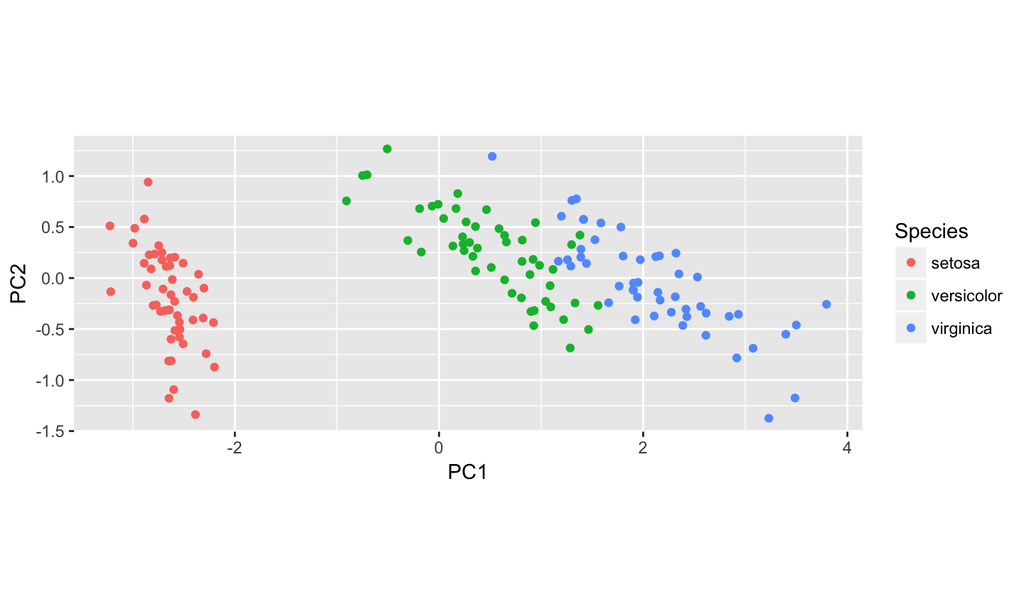

```r
ggplot(plot_iris, aes(x=PC1, y=PC2, color=Species)) + geom_point()  + coord_fixed()
```

## Plotting the PCA in 2D

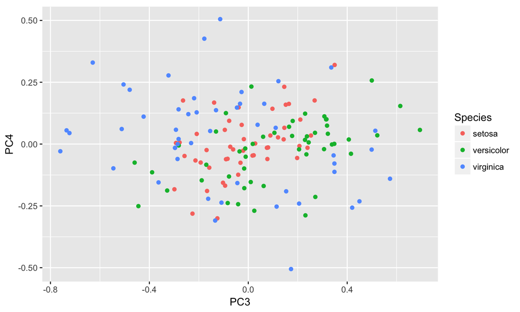

```r
ggplot(plot_iris, aes(x=PC3, y=PC4, color=Species)) + geom_point() + coord_fixed()
```

## Base plotting of the same thing

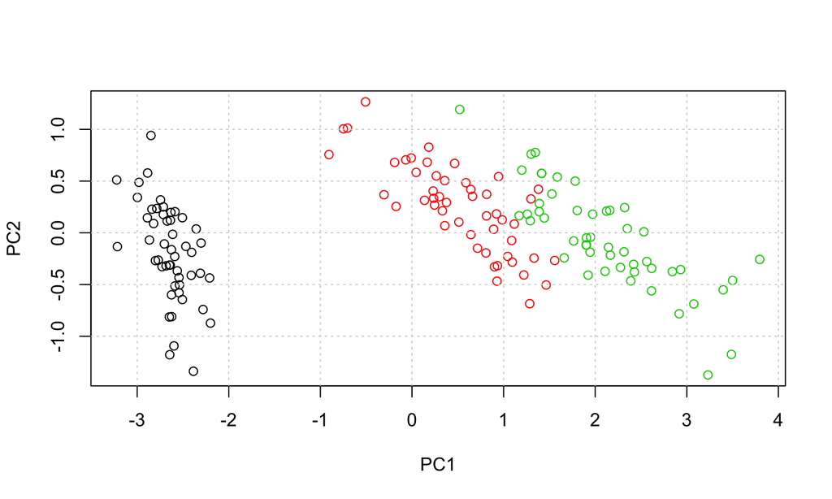

```r
with(plot_iris, plot(x=PC1, y=PC2, col=Species)); grid()
```

## Exercise 1: The `oliveoil` dataset

Repeat the previous analysis for the the `oliveoil` dataset from the `pdfCluster` package!

1. Load the data, and determine the dimensionality.
2. Perform the PCA
3. Inspect the amount of variance explained by each PC
4. Make a plot of the samples using `PC1` & `PC2` and `PC2` & `PC3`
5. Do you see any pattern? Discuss with the people near you.

I highly suggest you try writing the code yourself! If you are struggling, you can look at the cheatsheets on the following slides.

We will go around the room to answer questions.

## Cheat sheet: Loading the data

```r
# Load the data
suppressPackageStartupMessages(library(pdfCluster))
data(oliveoil)

# Size of the dataframe
dim(oliveoil)
```

```
## [1] 572  10
```

```r
# First few lines of the dataset
head(oliveoil)
```

```
##   macro.area       region palmitic palmitoleic stearic oleic linoleic
## 1      South Apulia.north     1075          75     226  7823      672
## 2      South Apulia.north     1088          73     224  7709      781
## 3      South Apulia.north      911          54     246  8113      549
## 4      South Apulia.north      966          57     240  7952      619
## 5      South Apulia.north     1051          67     259  7771      672
## 6      South Apulia.north      911          49     268  7924      678
##   linolenic arachidic eicosenoic
## 1        36        60         29
## 2        31        61         29
## 3        31        63         29
## 4        50        78         35
## 5        50        80         46
## 6        51        70         44
```

## Cheat sheet: Summarising the data

```r
# Summary statistics
summary(oliveoil)
```

```
##         macro.area              region       palmitic     palmitoleic
##  South       :323   Apulia.south   :206   Min.   : 610   Min.   : 15.00
##  Sardinia    : 98   Sardinia.inland: 65   1st Qu.:1095   1st Qu.: 87.75
##  Centre.North:151   Calabria       : 56   Median :1201   Median :110.00
##                     Umbria         : 51   Mean   :1232   Mean   :126.09
##                     Liguria.east   : 50   3rd Qu.:1360   3rd Qu.:169.25
##                     Liguria.west   : 50   Max.   :1753   Max.   :280.00
##                     (Other)        : 94
##     stearic          oleic         linoleic        linolenic
##  Min.   :152.0   Min.   :6300   Min.   : 448.0   Min.   : 0.00
##  1st Qu.:205.0   1st Qu.:7000   1st Qu.: 770.8   1st Qu.:26.00
##  Median :223.0   Median :7302   Median :1030.0   Median :33.00
##  Mean   :228.9   Mean   :7312   Mean   : 980.5   Mean   :31.89
##  3rd Qu.:249.0   3rd Qu.:7680   3rd Qu.:1180.8   3rd Qu.:40.25
##  Max.   :375.0   Max.   :8410   Max.   :1470.0   Max.   :74.00
##
##    arachidic       eicosenoic
##  Min.   :  0.0   Min.   : 1.00
##  1st Qu.: 50.0   1st Qu.: 2.00
##  Median : 61.0   Median :17.00
##  Mean   : 58.1   Mean   :16.28
##  3rd Qu.: 70.0   3rd Qu.:28.00
##  Max.   :105.0   Max.   :58.00
##
```

## Cheat sheet: Analysing the data

Example code for performing the PCA:

```r
# PCA without the first two columns
pca_oil <- prcomp(oliveoil[,-c(1,2)])

# Save the data for plotting
plot_oil <- data.frame(pca_oil$x, oliveoil[,1:2])
```

Go back in the slides: Which object can you call the `summary` function on to inspect the contained variance?

## Plotting the PCA in 2D

Try playing around with different combinations of PCs by editing the code below:

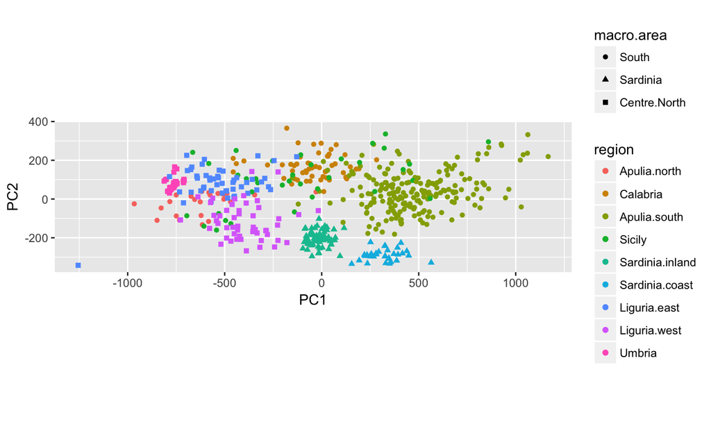

```r
ggplot(plot_oil, aes(x=PC1, y=PC2, color=region, shape=macro.area)) + geom_point() + coord_fixed()
```

## Wrapping up

PCA is one of the most widely used methods for dimensionality reduction - but by not the only one!

We have skipped over some very important concepts in the this very shorts introduction:

- The relation between PCA and Singular Value Decomposition (SVD): how the PCA is actually calculated.
- Loading of features: How "important" features are for the different PCs
- Scaling of the data: How to combine measurements on different scales (Play around with this using the `prcomp(scale=TRUE)` argument).

Other popular methods not covered here:

- Multidimensional scaling (MDS)
- t-distributed Stochastic Neighbor Embedding (t-SNE)
- Clustered heatmaps (see package `pheatmap`)

## The `zebrafish` dataset

Next is a worked example on a real RNA-Seq dataset:

- Dataset from the paper: *Silencing of odorant receptor genes by G protein βγ signaling ensures the expression of one odorant receptor per olfactory sensory neuron* by Ferreira *et al*.
- URL to paper: https://www.ncbi.nlm.nih.gov/pubmed/24559675
- RNA-Seq data for **6** Zebrafish samples.
- Samples grouped by Gallein treated (Trt) or untreated controls (Ctl)
- The data contains raw counts for both genes and so-called experimental spike-ins (which we won't use)

```r
library(Shenzen2016)
data("zebrafish")
```

## Trimming the data

As explained earlier, we need to trim and normalize the data.

Let's first discard genes with less than 10 reads in in three samples

```r
above_threshold <- rowSums(zebrafish$Expression >= 10) >= 3
EM_zebra <- subset(zebrafish$Expression, above_threshold)
```

The threshold on which to trim is somewhat arbitrary and depends heavily on the given dataset. Often you set the threshold for expression on what can be externally experimentally validated.

## Normalizing the data

We then use `edgeR` to normalize the data. First we have to store the data as a `DGEList`

```r
library(edgeR)
# Create dge list object
dge_zebra <- DGEList(EM_zebra)

# Calculate normalization factors
dge_zebra <- calcNormFactors(dge_zebra, method="TMM")

# Normalize the expression values
logTMM_zebra <- cpm(dge_zebra, log=TRUE, prior.count=3)
```

## Performing the PCA

We perform the PCA just as before. We have to transpose the EM first, since genomic data is usually stored with samples as columns rather than rows:

```r
pca_zebra <- prcomp(t(logTMM_zebra))
summary(pca_zebra)
```

```
## Importance of components:
##                             PC1     PC2    PC3     PC4     PC5      PC6
## Standard deviation     115.1460 91.6886 76.084 70.2892 61.4561 1.62e-13
## Proportion of Variance   0.3665  0.2324  0.160  0.1366  0.1044 0.00e+00
## Cumulative Proportion    0.3665  0.5990  0.759  0.8956  1.0000 1.00e+00
```

## Extracting the PCs

```r
plot_zebra <- data.frame(pca_zebra$x, zebrafish$Design)
head(plot_zebra)
```

```
##               PC1       PC2       PC3       PC4        PC5           PC6
## Ctl1    -3.188810  33.34284 118.96394 -81.36881 -30.649326  1.475955e-13
## Ctl3    63.552371 -11.18400  30.22010  27.76598 115.520438  3.250525e-14
## Ctl5    72.679275 -47.27421  28.28460 105.41947 -64.888831  4.945384e-13
## Trt9    -5.554483 167.62094 -66.22776  13.45747 -10.252984  4.079168e-13
## Trt11 -219.955817 -58.77003 -20.23342  11.44407   6.019289 -1.131886e-12
## Trt13   92.467464 -83.73554 -91.00746 -76.71819 -15.748585  6.763600e-14
##       gallein
## Ctl1  control
## Ctl3  control
## Ctl5  control
## Trt9  treated
## Trt11 treated
## Trt13 treated
```

## Plotting the PCA in 2D

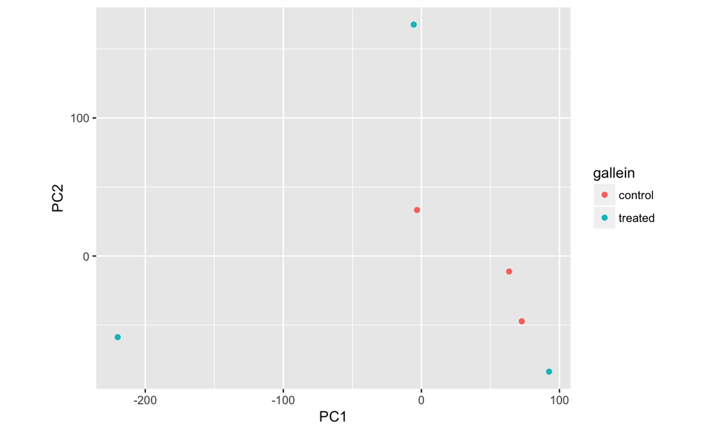

```r
ggplot(plot_zebra, aes(x=PC1, y=PC2, color=gallein)) + geom_point() + coord_fixed()
```

## Plotting the PCA in 2D

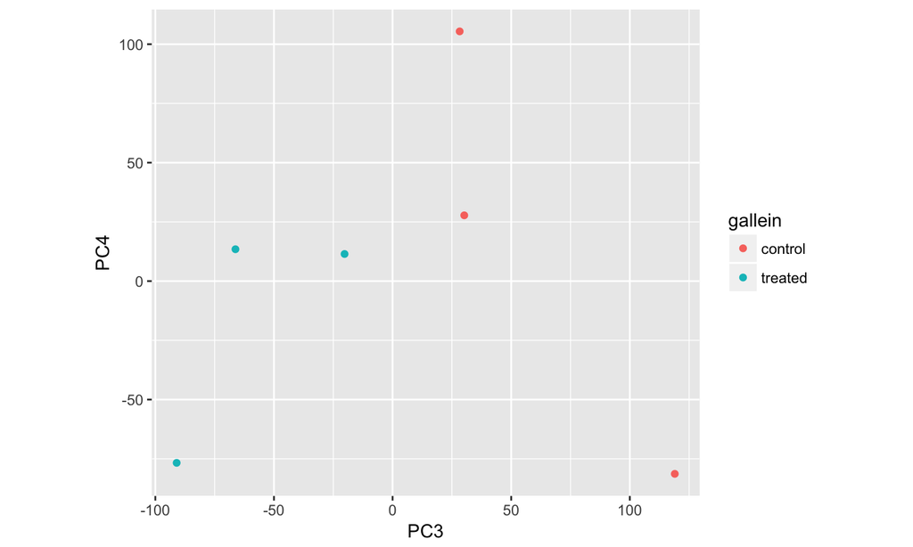

```r
ggplot(plot_zebra, aes(x=PC3, y=PC4, color=gallein)) + geom_point() + coord_fixed()
```

## Interpreting the plot

What does the plot mean?

- Is this what you expected to see?
- What could be the explanation?
- Experiments are not guaranteed to look like how you want them!

## Exercise 2: The `yeast` dataset

- Dataset from the paper: *A global non-coding RNA system modulates fission yeast protein levels in response to stress.* by Leong *et al*.
- URL to paper: https://www.ncbi.nlm.nih.gov/pubmed/24559675
- RNA-Seq data for **12** fission samples.
- Contains wildtype (wt) and mutant (mut) strains, with a transcription factor mutated.
- Contains samples at 0 and 30 minutes after stress stimulation.
- The data contains raw counts for genes.

## Exercise 2: The `pasilla` dataset

- Dataset from the paper: *Conservation of an RNA regulatory map between Drosophila and mammals.* by Brooks *et al*.
- URL to paper: https://www.ncbi.nlm.nih.gov/pmc/articles/PMC3032923/
- RNA-Seq data for **7** drosophila samples.
- Contains treated and untreated (knock down) samples, prepared using two different protocols.
- The data contains raw counts for genes.

## Exercise 2: The `tissues` dataset

- Dataset from the paper: *Alternative isoform regulation in human tissue transcriptomes..* by Wang *et al*.
- URL to paper: http://www.ncbi.nlm.nih.gov/pubmed?term=18978772
- RNA-Seq data for **22** human tissue samples.
- Samples sorted by cell type or tissue type.
- The data contains raw counts for genes.

## Exercise 2: PCA using R

Repeat the previous analysis for the the `yeast`, `pasilla` and, if you have time, the `tissues` dataset.

1. Load the data, and determine the dimensionality.
2. Perform the PCA
3. Inspect the amount of variance explained by each PC
4. Make a plot of the samples using `PC1` & `PC2` and `PC2` & `PC3`
5. Do you see any pattern? Discuss with the people near you.

I highly suggest you try writing the code yourself! If you are struggling, you can look at the cheatsheets on the following slides.

We will go around the room to answer questions.

## Cheatsheet: Loading the data

Perfrom the PCA:

```r
# Load the data
data("yeast")
data("pasilla")
data("tissues")

# Inspect the dimensionality
dim(yeast$Expression)
```

```
## [1] 7039   12
```

```r
# Inspect the design by
yeast$Design
```

```
##            strain minute replicate        id
## GSM1368273     wt      0        r1   wt_0_r1
## GSM1368274     wt      0        r2   wt_0_r2
## GSM1368275     wt      0        r3   wt_0_r3
## GSM1368279     wt     30        r1  wt_30_r1
## GSM1368280     wt     30        r2  wt_30_r2
## GSM1368281     wt     30        r3  wt_30_r3
## GSM1368291    mut      0        r1  mut_0_r1
## GSM1368292    mut      0        r2  mut_0_r2
## GSM1368293    mut      0        r3  mut_0_r3
## GSM1368297    mut     30        r1 mut_30_r1
## GSM1368298    mut     30        r2 mut_30_r2
## GSM1368299    mut     30        r3 mut_30_r3
```

## Cheatsheet: Analysing the data

```r
# Set a dataset: either yeast, pasilla or tissues
dataset <- pasilla

# Trim: Play around with numbers here
EM <- subset(dataset$Expression, rowSums(dataset$Expression >= 5) >= 3)

# Calculate normalization factors: Play around with the method argument (RLE, "none")
dge <- calcNormFactors(DGEList(EM), method="TMM")

# Normalize the expression values (Advanced, play around with prior.count)
logTMM <- cpm(dge, log=TRUE, prior.count=5)

# Perform the PCA and save data for plotting
pca <- prcomp(t(logTMM))
plot_data <- data.frame(pca$x, dataset$Design)
```

## Cheatsheet: plotting

Play around with different components and settings for color and shape

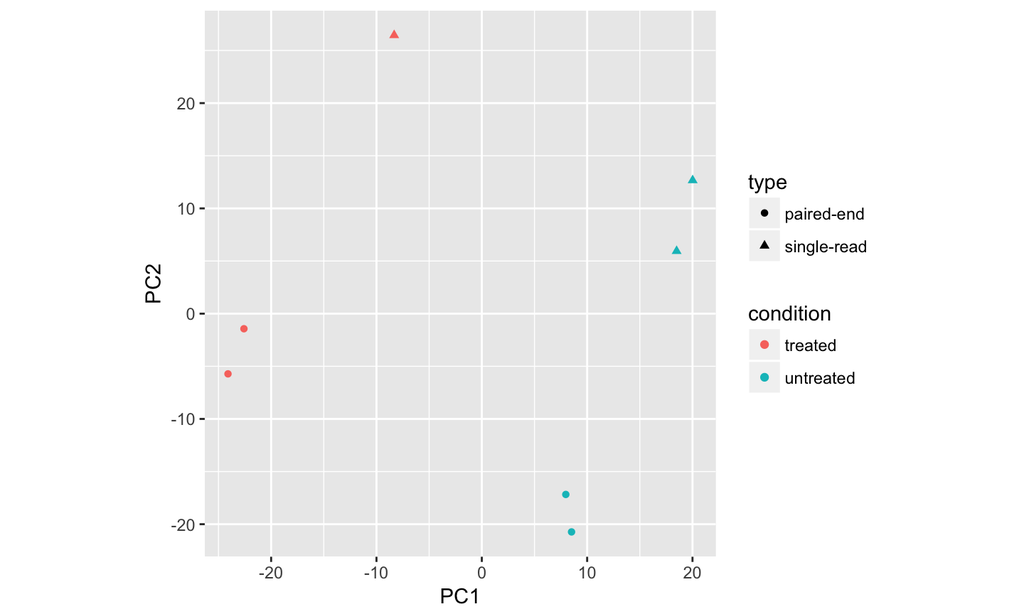

```r
ggplot(plot_data, aes(x=PC1, y=PC2, color=condition, shape=type)) + geom_point() + coord_fixed()
```